# HBSC: Data Overview and Prep

Updated: 2026-08-02

## Dataset Overview

File has the following rows and columns:

```
[1] 244097    120
```

Pretty much all columns have missing values so need to address later. Though it seems much of the variables I will care about don’t have much.

| variable | na_count | na_pct |
| --- | --- | --- |
| agesex | 228488 | 93.6 |
| contraceptpill | 228448 | 93.6 |
| contraceptcondom | 228070 | 93.4 |
| employnotfa | 224524 | 92.0 |
| employnotmo | 199890 | 81.9 |
| hadsex | 162986 | 66.8 |
| cannabis30d_2 | 144442 | 59.2 |
| cannabisltm_2 | 142745 | 58.5 |
| countrybornfa | 71901 | 29.5 |
| countrybornmo | 70659 | 28.9 |

[output cut: 110 more lines]

### seqno_int

This is the unique identifier of each record and I confirmed it’s unique.

```r
length(unique(dat$seqno_int)) == nrow(dat)
```

```
[1] TRUE
```

### countryno

Number of countries in dataset is:

```r
length(unique(dat$countryno))
```

```
[1] 47
```

And this is the count of survey responses by country:

| country_name | n | pct |
| --- | --- | --- |
| Wales | 15951 | 6.5 |
| Canada | 12950 | 5.3 |
| Czech Republic | 11564 | 4.7 |
| France | 9170 | 3.8 |
| NA | 8411 | 3.4 |
| Israel | 7712 | 3.2 |
| Switzerland | 7510 | 3.1 |
| Iceland | 6996 | 2.9 |
| Ukraine | 6660 | 2.7 |
| Portugal | 6126 | 2.5 |

[output cut: 36 more lines]

## Variables to Predict

### lifesat

Q: Here is a picture of a ladder. The top of the ladder “10” is the best possible life for you and the bottom “0” is the worst possible life for you. In general, where on the ladder do you feel you stand at the moment? A: 0-10

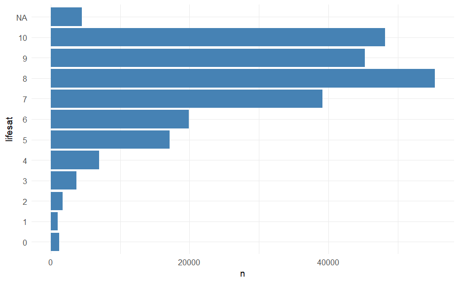

lifesat is dichotomized for modeling as lifesat_low:

```
           0     1  <NA>
  0        0  1218     0
  1        0  1041     0
  2        0  1748     0
  3        0  3691     0
  4        0  6961     0
  5        0 17137     0
  6    19921     0     0
  7    39120     0     0
  8    55325     0     0
  9    45271     0     0
  10   48152     0     0
  <NA>     0     0  4512
```

Ultimately the distribution is:

| lifesat_low | n | pct |
| --- | --- | --- |
| 0 | 207789 | 0.85125585 |
| 1 | 31796 | 0.13025969 |
| NA | 4512 | 0.01848445 |

### (mental) health complaints

There are 8 variables for this that reply to a question like: In the last 6 months: how often have you had the following….? And the answers goes from 1 About every day to 5 Rarely or never. The 8 variables are: headache, stomachache, backache, dizzy, feellow, irritable, nervous, sleepdificulty.

Their distributions look like this:

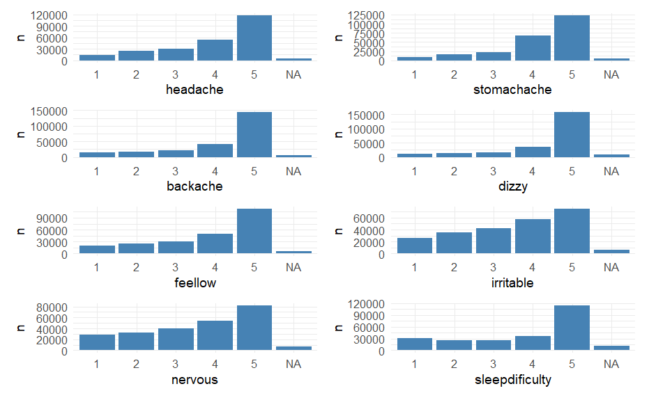

These variables are then recoded to a binary where it flags if the complaint occurs more than once per week (1 or 2).

The recoded variables look like this:

```
### headache x headache_frequent

            0      1   <NA>
  1         0  13883      0
  2         0  24257      0
  3     30076      0      0
  4     53676      0      0
  5    117700      0      0
  <NA>      0      0   4505


### stomachache x stomachache_frequent

            0      1   <NA>
  1         0   8415      0
  2         0  16223      0
  3     22895      0      0
  4     68018      0      0
  5    122867      0      0
  <NA>      0      0   5679


### backache x backache_frequent

            0      1   <NA>
  1         0  14872      0
  2         0  16137      0
  3     21410      0      0
  4     40910      0      0
  5    144225      0      0
  <NA>      0      0   6543


### dizzy x dizzy_frequent

            0      1   <NA>
  1         0  10461      0
  2         0  14272      0
  3     17261      0      0
  4     35189      0      0
```

[output cut: 31 more lines]

```
  3    40064     0     0
  4    54109     0     0
  5    82323     0     0
  <NA>     0     0  6525


### sleepdificulty x sleepdificulty_frequent

            0      1   <NA>
  1         0  30501      0
  2         0  25543      0
  3     26053      0      0
  4     36570      0      0
  5    114616      0      0
  <NA>      0      0  10814
```

```
### mental_complaintsY x mental_complaints_sum

            0      1   <NA>
  0    121573      0      0
  1     45509      0      0
  2         0  29991      0
  3         0  21172      0
  4         0  12970      0
  <NA>      0      0  12882


### (health_complaintsY x health_complaints_sum

            0      1   <NA>
  0    103678      0      0
  1     41923      0      0
  2         0  29221      0
  3         0  21360      0
  4         0  14640      0
  5         0   8824      0
  6         0   5202      0
  7         0   2839      0
  8         0   2219      0
  <NA>      0      0  14191
```

### mental_complaintsY

Ultimately our variable to predict will be mental_complaintsY; at ~26%.

| mental_complaintsY | n | pct |
| --- | --- | --- |
| 0 | 167082 | 0.6844902 |
| 1 | 64133 | 0.2627357 |
| NA | 12882 | 0.0527741 |

## The Predictors

### Problematic social media use (PMSU)

PMSU are the main variables of interest. There are 9 of them: emcsocmed1 to emcsocmed9. The prequestion for all of them is: We are interested in your experiences with social media. The term social media refers to social network sites (e.g. Facebook, [add other local examples]) and instant messengers (e.g. [insert local examples], WhatsApp, Snapchat, Facebook messenger). During the past year, have you…. Please tick one box for each line.

The possible answers are 1 (no) and 2 (yes). Also those with 99 mean Missing due to skip pattern.

The topic of each question is:

| item | topic |
| --- | --- |
| emcsocmed1 | Social media: I can’t think of anything else |
| emcsocmed2 | Social media: Dissatisfied cause want to spend more time |
| emcsocmed3 | Social media: Felt bad cause want to play |
| emcsocmed4 | Social media: Failed to spend less time |
| emcsocmed5 | Social media: Neglected other activities |
| emcsocmed6 | Social media: Had arguments because of use |
| emcsocmed7 | Social media: Lied about amount of time spent |
| emcsocmed8 | Social media: Use it to escape from negative feelings |
| emcsocmed9 | Social media: Conflict with family because of use |

The recoding looks like this:

```
## Table for emcsocmed1
            0      1   <NA>
  1    156598      0      0
  2         0  44267      0
  99        0      0  11259
  <NA>      0      0  31973


## Table for emcsocmed2
            0      1   <NA>
  1    163166      0      0
  2         0  38013      0
  99        0      0  11259
  <NA>      0      0  31659


## Table for emcsocmed3
            0      1   <NA>
  1    157891      0      0
  2         0  42938      0
  99        0      0  11259
  <NA>      0      0  32009


## Table for emcsocmed4
            0      1   <NA>
  1    138631      0      0
  2         0  61779      0
  99        0      0  11259
  <NA>      0      0  32428


## Table for emcsocmed5
            0      1   <NA>
  1    168967      0      0
  2         0  31428      0
  99        0      0  11259
  <NA>      0      0  32443


```

[output cut: 15 more lines]

```

## Table for emcsocmed8
            0      1   <NA>
  1    137767      0      0
  2         0  62193      0
  99        0      0  11259
  <NA>      0      0  32878


## Table for emcsocmed9
            0      1   <NA>
  1    171010      0      0
  2         0  28973      0
  99        0      0  11259
  <NA>      0      0  32855
```

And this gives an idea of how correlated they are with each other.

Is this right? Too correlated? Or it’s done different? It has to be done another way?

```
           emcsocmed1 emcsocmed2 emcsocmed3 emcsocmed4 emcsocmed5 emcsocmed6 emcsocmed7 emcsocmed8 emcsocmed9
emcsocmed1     1.0000     0.9998     0.9998     0.9997     0.9998     0.9998     0.9998     0.9997     0.9998
emcsocmed2     0.9998     1.0000     0.9998     0.9997     0.9998     0.9998     0.9998     0.9997     0.9998
emcsocmed3     0.9998     0.9998     1.0000     0.9997     0.9998     0.9998     0.9998     0.9997     0.9998
emcsocmed4     0.9997     0.9997     0.9997     1.0000     0.9997     0.9997     0.9998     0.9997     0.9998
emcsocmed5     0.9998     0.9998     0.9998     0.9997     1.0000     0.9998     0.9998     0.9997     0.9998
emcsocmed6     0.9998     0.9998     0.9998     0.9997     0.9998     1.0000     0.9998     0.9997     0.9998
emcsocmed7     0.9998     0.9998     0.9998     0.9998     0.9998     0.9998     1.0000     0.9998     0.9999
emcsocmed8     0.9997     0.9997     0.9997     0.9997     0.9997     0.9997     0.9998     1.0000     0.9998
emcsocmed9     0.9998     0.9998     0.9998     0.9998     0.9998     0.9998     0.9999     0.9998     1.0000
```

PMSU variables are then combined so output is represented in one variable, instead of 9. I will do 2 versions: a) Yes/No where Y(6-9) and N(0-5) b) H/M/L where H(6-9), M(2-5) and L(0-1)

The distribution of PMSU categorized is:

```
## Table for emcsocmed_sum x pmsu_yn
           0     1  <NA>
  0    72474     0     0
  1    36277     0     0
  2    26066     0     0
  3    19012     0     0
  4    14908     0     0
  5    10306     0     0
  6        0  5905     0
  7        0  3382     0
  8        0  1878     0
  9        0  2979     0
  <NA>     0     0 50910
## Table for emcsocmed_sum x pmsu_lmh
        high   low   med  <NA>
  0        0 72474     0     0
  1        0 36277     0     0
  2        0     0 26066     0
  3        0     0 19012     0
  4        0     0 14908     0
  5        0     0 10306     0
  6     5905     0     0     0
  7     3382     0     0     0
  8     1878     0     0     0
  9     2979     0     0     0
  <NA>     0     0     0 50910
## Table for pmsu_yn x pmsu_lmh
            0      1   <NA>
  high      0  14144      0
  low  108751      0      0
  med   70292      0      0
  <NA>      0      0  50910
```

### Family Support

There are 4 of them. The question starts with: We are interested in how you feel about the following statements. Please show how much you agree or disagree with each one. Please tick one box for each line.

The options to answer go from 1 Very strongly disagree to 7 Very strongly agree. The 4 questions are:

| item | topic |
| --- | --- |
| famhelp | Family tries to help |
| famsup | Get emotional help from family |
| famtalk | Talk about problems with family |
| famclose | Feel close to family |

These variables are then combined to create a categorical predictor. For now, I will keep two options like I did for PMSU but will select only one when modeling. These are:  
a) H/L based on avg of 4 vars. L if [1,5.5) and H if [5.5, 7]  
b) H/M/L based on sum of 4 vars. L if 4-11, M if 12-19, H if 20-28.

Their counts after recoding are:

family_support_high

| Var1 | Freq | pct |
| --- | --- | --- |
| 0 | 65676 | 0.269 |
| 1 | 156068 | 0.639 |
| NA | 22353 | 0.092 |

family_support_hml

| Var1 | Freq | pct |
| --- | --- | --- |
| high | 169660 | 0.695 |
| low | 23345 | 0.096 |
| med | 28739 | 0.118 |
| NA | 22353 | 0.092 |

### Frieds (Peer) Support

There are 4 friends support questions. The questions start with: We are interested in how you feel about the following statements. Please show how much you agree or disagree with each one. Please tick one box for each line.

The answers range from 1 Very strongly disagree to 7 Very strongly agree.

| item | topic |
| --- | --- |
| friendhelp | My friends really try to help me |
| friendcounton | I can count on my friends when things go wrong |
| friendshare | I have friends with whom I can share my joys and sorrows |
| friendtalk | I can talk about my problems with my friends |

These variables are then combined to create a categorical predictor. For now, I will keep two options like I did for family but will select only one when modeling. These are:  
a) H/L based on avg of 4 vars. L if [1,5.5) and H if [5.5, 7]  
b) H/M/L based on sum of 4 vars. L if 4-11, M if 12-19, H if 20-28.

Their counts after recoding are:

friends_support_high

| Var1 | Freq | pct |
| --- | --- | --- |
| 0 | 95821 | 0.393 |
| 1 | 135380 | 0.555 |
| NA | 12896 | 0.053 |

friends_support_hml

| Var1 | Freq | pct |
| --- | --- | --- |
| high | 155201 | 0.636 |
| low | 29537 | 0.121 |
| med | 46463 | 0.190 |
| NA | 12896 | 0.053 |

### IRRELFAS_LMH: Relative family affluence categorical

Derived from IRFAS. So check list of fas-variables in the dataset. It is a cut based on percentiles so I recode to friendly. 1 Lowest 20 pct  
2 Medium 60 pct  
3 Highest 20 pct

IRRELFAS_LMH x IRRELFAS_LMH_r

|  | High20 | Low20 | Med60 | NA |
| --- | --- | --- | --- | --- |
| 1 | 0 | 45818 | 0 | 0 |
| 2 | 0 | 0 | 142148 | 0 |
| 3 | 43532 | 0 | 0 | 0 |
| NA | 0 | 0 | 0 | 12599 |

### talkfather and talkmother

Two questions measure parent communication. The pre-question is: How easy is it for you to talk to the following persons about things that really bother you? Please tick one box for each line

Answers go from 1 Very easy to 5 Don’t have or see.

These are dichotomized for each parent as Yes if [1,2] and No if [3-5].

```
## Table for talkfatherYes x talkfather
           0     1  <NA>
  1        0 73777     0
  2        0 78346     0
  3    40289     0     0
  4    19010     0     0
  5    15184     0     0
  <NA>     0     0 17491
## Table for talkmotherYes x talkmother
            0      1   <NA>
  1         0 115899      0
  2         0  74913      0
  3     24042      0      0
  4      9276      0      0
  5      4446      0      0
  <NA>      0      0  15521
```

I was going to combine to a “number of parents one can talk” but I’ll leave for now and will try as interactions later.

### bullying victim

There are 2 variables that measure if kid has been bullied. a) beenbullied: Been bullied past months and b) cbeenbullied: Been cyber bullied. Answers range from 1 Haven’t to 5 Several times a week.

These are dichotomized as Yes if [2-5] and No if [1].

```
## Table for beenbullied x beenbulliedYes
            0      1   <NA>
  1    166254      0      0
  2         0  36624      0
  3         0   9754      0
  4         0   6179      0
  5         0   8324      0
  <NA>      0      0  16962
## Table for cbeenbullied x cbeenbulliedYes
            0      1   <NA>
  1    198900      0      0
  2         0  20426      0
  3         0   4625      0
  4         0   2274      0
  5         0   2788      0
  <NA>      0      0  15084
```

### age and sex(gender)

There are 3 age groups and 2 genders. I recode to friendly/actual value and they look like this.

```
## Table for agecat x age_r
          11    13    15  <NA>
  1    81834     0     0     0
  2        0 83749     0     0
  3        0     0 76998     0
  <NA>     0     0     0  1516
## Table for sex x sex_r
          boy   girl   <NA>
  1    120350      0      0
  2         0 123747      0
  <NA>      0      0      0
## Table for age_r x sex_r
         boy  girl  <NA>
  11   40476 41358     0
  13   41612 42137     0
  15   37394 39604     0
  <NA>   868   648     0
```

## Dataset for Modeling

Only the relevant and prepared variables are exported to a csv so I can start the modeling process with those. File goes to “data/processed/” and includes date.